# Procesamiento de imágenes satelitales meteorológicas con Python 2022.

## Practico 1.

Objetivos:

Familiarizarse con objetos de Python

1. Familiarizarse con las librerı́as numpy y matplotlib
2. Realizar algunas operaciones básicas de realce.
3. Obtener histogramas y realizar manipulaciones.
4. Jugar con combinaciones de bandas para un análisis visual intuitivo.

Primeramente se configura el directorio de trabajo dentro del Drive en donde está la imagen crome.tif

```python
#?Configuro mi ruta de acceso para IO de archivos
import os
import numpy as np
from matplotlib import pyplot as plt
import matplotlib.image as mpimg

direct = 'C:/Users/marti/Desktop/Procesamiento Imagenes Satelitales 2022/guia1/' #modificar esta linea
os.chdir(direct)
```

Levantamos la imagen y la desplegamos

[figure not shown]

```python
crome = mpimg.imread(direct + 'crome.tif')
plt.figure(figsize=(10,5))
plt.title('Imagen original')
plt.imshow(crome, vmin=0, vmax=127)
plt.show()
```

Analizar el array.

- Cuáles son sus dimensiones?
- Cuales son los rangos de los datos?
- Cuáles serían las bandas que corresponden a los colores?

### Dimensiones:

```python
print(crome.shape)
```

```
(512, 512, 4)
```

### Rango de los datos:

```python
print("Red")
print(np.amin(crome[:,:,0]))
print(np.amax(crome[:,:,0]))

print("Green")
print(np.amin(crome[:,:,1]))
print(np.amax(crome[:,:,1]))

print("Blue")
print(np.amin(crome[:,:,2]))
print(np.amax(crome[:,:,2]))
```

```
Red
0
127
Green
0
127
Blue
0
127
```

Error1: Es el maximo y minimo de cada una de las bandas no de crome porque me toma la mascara y es 255.

RGBA formato de imagen. A es para enmascarar. (M, N, 4): an image with RGBA values (0-1 float or 0-255 int), i.e. including transparency.

Mostrar la imagen original en color y c/u de los canales de datos en grises usando *plt.subplot*

[figure not shown]

```python
# crome = mpimg.imread(direct + 'crome.tif')
r=crome[:,:,0]
g= crome[:,:,1]
b=crome[:,:,2]
mask=crome[:,:,3]

plt.figure(figsize=(10,5))
plt.subplot(2,2,1)
plt.title('Imagen original')
plt.imshow(crome, vmin=0, vmax=127)
plt.subplot(2,2,2)
plt.title('Red')
plt.imshow(r, vmin=0, vmax=127, cmap="gray")
plt.subplot(2,2,3)
plt.title('Green')
plt.imshow(g, vmin=0, vmax=127, cmap="gray")
plt.subplot(2,2,4)
plt.title('Blue')
plt.imshow(b, vmin=0, vmax=127, cmap="gray")

plt.tight_layout()
plt.show()
```

- Las primeras tres son RGB y la ultima es la mascara.
- La primera es la imagen y las otras son las bandas de RGB.

Obtener los histogramas para cada canal de datos usando *np.histogram* y graficarlos uno encima del otro.

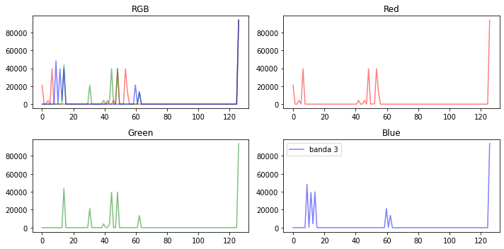

```python
frec1,val1=np.histogram(r, bins=100)
frec2,val2=np.histogram(g, bins=100)
frec3,val3=np.histogram(b, bins=100)

plt.figure(figsize=(10,5))
plt.subplot(2,2,1)
plt.title('RGB')
plt.plot(val1[:-1],frec1, alpha=0.5, label='banda 1',color="r")
plt.plot(val2[:-1],frec2, alpha=0.5, label='banda 2',color="g")
plt.plot(val3[:-1],frec3, alpha=0.5, label='banda 3',color="b")

plt.subplot(2,2,2)
plt.title('Red')
plt.plot(val1[:-1],frec1, alpha=0.5, label='banda 1',color="r")

plt.subplot(2,2,3)
plt.title('Green')
plt.plot(val2[:-1],frec2, alpha=0.5, label='banda 2',color="g")

plt.subplot(2,2,4)
plt.title('Blue')
plt.plot(val3[:-1],frec3, alpha=0.5, label='banda 3',color="b")

plt.tight_layout()
plt.legend()
plt.show()
```

Hacer una función que produzca un realce lineal. Esta función será una transformación lineal (con 2 parámetros de entrada además del array a transformar) que lleve los valores de [0 a 255] a [0 a 1]. Ası́, además de realzar se están normalizando los valores y pasamos de pixeles en uint8 (enteros sin signo de 8 bits) a flotantes.

## Hago el normalizado

```python
normalizado = (crome - np.amin(crome[:,:,0])) / (np.amax(crome[:,:,0])-np.amin(crome[:,:,0]))
```

```python
normalizado.dtype
# Esto no estaria mal tampoco.
```

```
dtype('float64')
```

```python
print("Red")
print(np.amin(normalizado[:,:,0]))
print(np.amax(normalizado[:,:,0]))

print("Green")
print(np.amin(normalizado[:,:,1]))
print(np.amax(normalizado[:,:,1]))

print("Blue")
print(np.amin(normalizado[:,:,2]))
print(np.amax(normalizado[:,:,2]))
```

```
Red
0.0
1.0
Green
0.0
1.0
Blue
0.0
1.0
```

```python
# new = norm(crome,0,1)
# new.shape
# print(new.dtype)
# print(crome.dtype)
```

[output not shown]

### Repito el grafico con el realce

```
Clipping input data to the valid range for imshow with RGB data ([0..1] for floats or [0..255] for integers).
```

[figure not shown]

```python
r2=normalizado[:,:,0]
g2=normalizado[:,:,1]
b2=normalizado[:,:,2]
mask2=normalizado[:,:,3]

plt.figure(figsize=(10,5))
plt.subplot(2,2,1)
plt.title('RGB')
plt.imshow(normalizado, vmin=0, vmax=1)
plt.subplot(2,2,2)
plt.title('Red')
plt.imshow(r2, vmin=0, vmax=1, cmap="gray")
plt.subplot(2,2,3)
plt.title('Green')
plt.imshow(g2, vmin=0, vmax=1, cmap="gray")
plt.subplot(2,2,4)
plt.title('Blue')
plt.imshow(b2, vmin=0, vmax=1, cmap="gray")

plt.tight_layout()
plt.show()
```

## Imagen con realce lineal

Aplicar el realce lineal a c/u de las bandas tal que lleve el valor mínimo original a 0 y el máximo original a 1. Luego desplegar la imagen realzada.

```
Clipping input data to the valid range for imshow with RGB data ([0..1] for floats or [0..255] for integers).
```

[figure not shown]

```python
plt.figure(figsize=(10,5))
plt.subplot(1,2,1)
plt.title('Original')
plt.imshow(crome, vmin=0,vmax=250)
plt.subplot(1,2,2)
plt.title('Realzada')
plt.imshow(normalizado,vmin=0,vmax=1)
plt.tight_layout()
plt.show()
```

A partir de aquí trabaje con la imagen realzada Generar el histograma de la imagen y comparar con el original.

- Qué puede observar?
- Piense en hipótesis de qué picos podrı́an corresponder a distintas regiones de la imagen y registre las bases de esas hipótesis (valores, frecuencia, etc)

Identifique coordenadas (fila, columna) en la imagen de distintas regiones y obtenga sus valores y compare con los histogramas para determinar qué picos podrı́an corresponder a las distintas regiones de la imagen y contraste con las hipótesis del punto anterior.

```
Clipping input data to the valid range for imshow with RGB data ([0..1] for floats or [0..255] for integers).
```

[figure not shown]

```python
frec12,val12=np.histogram(r2, bins=100)
frec22,val22=np.histogram(g2, bins=100)
frec32,val32=np.histogram(b2, bins=100)

r2=normalizado[:,:,0]
g2=normalizado[:,:,1]
b2=normalizado[:,:,2]
mask2=normalizado[:,:,3]

plt.figure(figsize=(10,10))
plt.subplot(4,2,1)
plt.title('RGB')
plt.imshow(normalizado, vmin=0, vmax=1)

plt.subplot(4,2,2)
plt.plot(val12[:-1],frec12, alpha=0.5, label='banda 1',color="r")
plt.plot(val22[:-1],frec22, alpha=0.5, label='banda 2',color="g")
plt.plot(val32[:-1],frec32, alpha=0.5, label='banda 3',color="b")

plt.subplot(4,2,3)
plt.title('Red')
plt.imshow(r2, vmin=0, vmax=1, cmap="gray")
plt.subplot(4,2,4)
plt.plot(val12[:-1],frec12, alpha=0.5, label='banda 1',color="r")

plt.subplot(4,2,5)
plt.title('Green')
plt.imshow(g2, vmin=0, vmax=1, cmap="gray")
plt.subplot(4,2,6)
plt.plot(val22[:-1],frec22, alpha=0.5, label='banda 2',color="g")

plt.subplot(4,2,7)
plt.title('Blue')
plt.imshow(b2, vmin=0, vmax=1, cmap="gray")
plt.subplot(4,2,8)
plt.plot(val32[:-1],frec32, alpha=0.5, label='banda 3',color="b")

plt.tight_layout()
plt.legend()
plt.show()
```

Los picos en la escala de la x corresponden a las distintas tonalidades de los colores, mientras que en el eje de las y podemos ver la cantidad de puntos, mayores valores areas mas grandes, menores valores areas mas pequeñas.

El 1 es el borde la mascara, el fondo. Cada pico corresponde a una determinada region hablar de ello.

#### Histograma para la imagen nueva

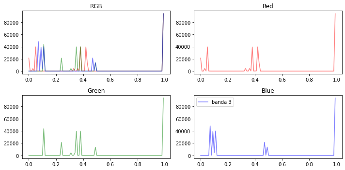

```python
plt.figure(figsize=(10,5))
frec12,val12=np.histogram(r2, bins=100)
frec22,val22=np.histogram(g2, bins=100)
frec32,val32=np.histogram(b2, bins=100)

plt.subplot(2,2,1)
plt.title('RGB')
plt.plot(val12[:-1],frec12, alpha=0.5, label='banda 1',color="r")
plt.plot(val22[:-1],frec22, alpha=0.5, label='banda 2',color="g")
plt.plot(val32[:-1],frec32, alpha=0.5, label='banda 3',color="b")

plt.subplot(2,2,2)
plt.title('Red')
plt.plot(val12[:-1],frec12, alpha=0.5, label='banda 1',color="r")

plt.subplot(2,2,3)
plt.title('Green')
plt.plot(val22[:-1],frec22, alpha=0.5, label='banda 2',color="g")

plt.subplot(2,2,4)
plt.title('Blue')
plt.plot(val32[:-1],frec32, alpha=0.5, label='banda 3',color="b")

plt.tight_layout()
plt.legend()
plt.show()
```

En el canal rojo el verde sale negro. El verde en el canal verde tiene valores altos. En el canal verde verde y amarillo salen mas claritos, el rojo sale negro.

## Filtro

Centre el análisis del punto anterior para fabricar un **filtro** para el canal verde, es decir que haga una máscara booleana que sea *True* en las región elegida.

Para ello debe analizar que valores en los histogramas corresponde a la región elegida.

Busco los dos valores de las tonalidades de verde, y a partir de alli filtro los valores que tengan ese valor

Filtrar: identificar que pixeles cumplen o no una determinada condicion. En el canal verde tambien sale el amarillo, este no quiero pintarlo.

```python
filtro = (normalizado[:, : , 1] > 0.2) * (normalizado[:, : , 1] < 0.35)  #ejemplo de una máscara booleana
# filtro
```

Pintar sobre la imagen de crome original la región filtrada de color verde puro

```python
filtro2=filtro.astype("int")
# np.amax(filtro2)
```

Si ha pintado otras regiones que no son verdes ajustar el filtro involucrando más bandas.

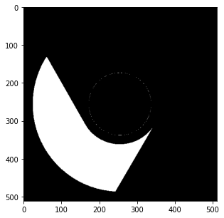

```python
filtro = (normalizado[:, : , 1] > 0.31) * (normalizado[:, : , 1] < 0.36) * (normalizado[:, : , 0] < 0.3)  #ejemplo de una máscara booleana
filtro2=filtro.astype("int")
plt.figure(figsize=(10,5))
plt.imshow(filtro2, vmin=0, vmax=1, cmap="gray")
```

#### Canal verde

```python
print("Cuña amarilla")
print(normalizado[:, : , 1][150,400]),
print("Cuña verde")
print(normalizado[:, : , 1][400,270])
print("Verde")
print(normalizado[:, : , 1][400,200])
```

```
Cuña amarilla
0.33070866141732286
Cuña verde
0.31496062992125984
Verde
0.3543307086614173
```

### Canal rojo

Para terminar de separar el amarillo necesito ver en el canal rojo que valores tiene

```python
print("Cuña amarilla")
print(normalizado[:, : , 0][150,400]),
print("Cuña verde")
print(normalizado[:, : , 0][400,270])
print("Verde")
print(normalizado[:, : , 0][400,200])
```

```
Cuña amarilla
0.3700787401574803
Cuña verde
0.03937007874015748
Verde
0.05511811023622047
```

[figure not shown]

```python
plt.figure(figsize=(10,5))
crome2 = np.copy(normalizado[:,:,:3])
ind = np.argwhere(filtro2)
crome2[ind[:,0],ind[:,1],1]=1
crome2[ind[:,0],ind[:,1],0]=0
crome2[ind[:,0],ind[:,1],2]=0
plt.imshow(crome2, vmin=0,vmax=1)
```

Repita todos los puntos anteriores sobre la imagen **face.png**

# Mapache

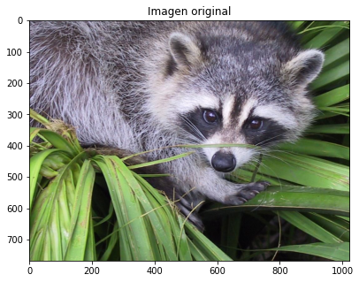

```python
mapache = mpimg.imread(direct + 'face.png')
plt.figure(figsize=(10,5))
plt.title('Imagen original')
plt.imshow(mapache, vmin=0, vmax=127)
plt.show()
```

```python
print(mapache.shape)
```

```
(768, 1024, 3)
```

```python
print("Red")
print(np.amin(mapache[:,:,0]))
print(np.amax(mapache[:,:,0]))

print("Green")
print(np.amin(mapache[:,:,1]))
print(np.amax(mapache[:,:,1]))

print("Blue")
print(np.amin(mapache[:,:,2]))
print(np.amax(mapache[:,:,2]))
```

```
Red
0.0
1.0
Green
0.0
0.9882353
Blue
0.0
1.0
```

La imagen ya esta realzada y no tiene mascara.

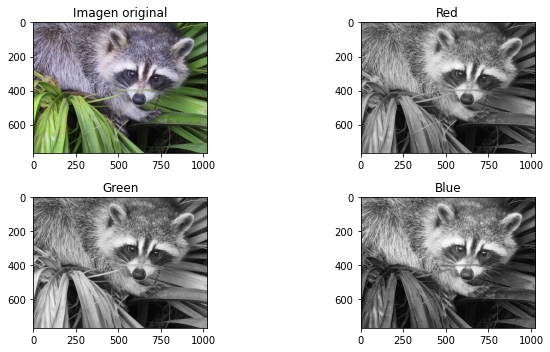

```python
r=mapache[:,:,0]
g= mapache[:,:,1]
b=mapache[:,:,2]

plt.figure(figsize=(10,5))
plt.subplot(2,2,1)
plt.title('Imagen original')
plt.imshow(mapache)
plt.subplot(2,2,2)
plt.title('Red')
plt.imshow(r, cmap="gray")
plt.subplot(2,2,3)
plt.title('Green')
plt.imshow(g, cmap="gray")
plt.subplot(2,2,4)
plt.title('Blue')
plt.imshow(b, cmap="gray")

plt.tight_layout()
plt.show()
```

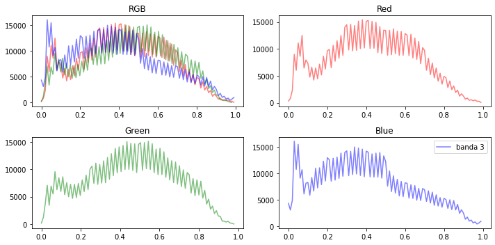

```python
plt.figure(figsize=(10,5))
frec1,val1=np.histogram(r, bins=100)
frec2,val2=np.histogram(g, bins=100)
frec3,val3=np.histogram(b, bins=100)

plt.plot(val1[:-1],frec1, alpha=0.5, label='banda 1',color="r")
plt.plot(val2[:-1],frec2, alpha=0.5, label='banda 2',color="g")
plt.plot(val3[:-1],frec3, alpha=0.5, label='banda 3',color="b")

plt.subplot(2,2,1)
plt.title('RGB')
plt.plot(val1[:-1],frec1, alpha=0.5, label='banda 1',color="r")
plt.plot(val2[:-1],frec2, alpha=0.5, label='banda 2',color="g")
plt.plot(val3[:-1],frec3, alpha=0.5, label='banda 3',color="b")

plt.subplot(2,2,2)
plt.title('Red')
plt.plot(val1[:-1],frec1, alpha=0.5, label='banda 1',color="r")

plt.subplot(2,2,3)
plt.title('Green')
plt.plot(val2[:-1],frec2, alpha=0.5, label='banda 2',color="g")

plt.subplot(2,2,4)
plt.title('Blue')
plt.plot(val3[:-1],frec3, alpha=0.5, label='banda 3',color="b")

plt.tight_layout()
plt.legend()
plt.show()
```

Mucha mas superposicion como consecuencia de que hay mayor rango de colores.

```
No artists with labels found to put in legend.  Note that artists whose label start with an underscore are ignored when legend() is called with no argument.
```

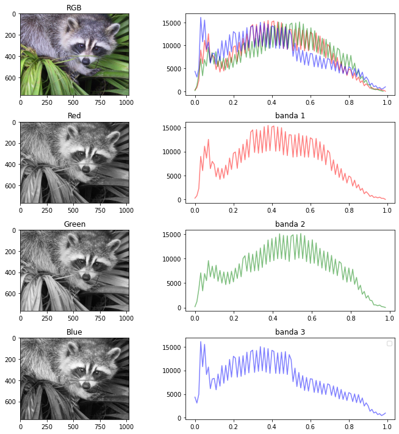

```python
plt.figure(figsize=(10,10))
plt.subplot(4,2,1)
plt.title('RGB')
plt.imshow(mapache, vmin=0, vmax=1)

plt.subplot(4,2,2)
plt.plot(val1[:-1],frec1, alpha=0.5, label='banda 1',color="r")
plt.plot(val2[:-1],frec2, alpha=0.5, label='banda 2',color="g")
plt.plot(val3[:-1],frec3, alpha=0.5, label='banda 3',color="b")

plt.subplot(4,2,3)
plt.title('Red')
plt.imshow(r, vmin=0, vmax=1, cmap="gray")
plt.subplot(4,2,4)
plt.title('banda 1')
plt.plot(val1[:-1],frec1, alpha=0.5, label='banda 1',color="r")

plt.subplot(4,2,5)
plt.title('Green')
plt.imshow(g, vmin=0, vmax=1, cmap="gray")
plt.subplot(4,2,6)
plt.title('banda 2')
plt.plot(val2[:-1],frec2, alpha=0.5, label='banda 2',color="g")

plt.subplot(4,2,7)
plt.title('Blue')
plt.imshow(b, vmin=0, vmax=1, cmap="gray")
plt.subplot(4,2,8)
plt.title('banda 3')
plt.plot(val3[:-1],frec3, alpha=0.5,color="b")

plt.tight_layout()
plt.legend()
plt.show()
```

El verde es el que mas aporta a la planta porque es en donde mas brillante se ve.

```python
filtro = (normalizado[:, : , 1] > 0.2) * (normalizado[:, : , 1] < 0.35)  #ejemplo de una máscara booleana
# filtro
```

```python
filtro2=filtro.astype("int")
# np.amax(filtro2)
```

Exploro valores de la planta en distintos canales

Canal rojo

```python
print(mapache[:, : , 0][650,50]),
print(mapache[:, : , 0][650,100]),
print(mapache[:, : , 0][650,200]),
print(mapache[:, : , 0][450,10]),
print(mapache[:, : , 0][650,300]),
print(mapache[:, : , 0][650,400]),
print(mapache[:, : , 0][650,500]),
print(mapache[:, : , 0][580,1000])

print("Nuevos")
print(mapache[:, : , 0][700,390])
print(mapache[:, : , 0][710,400])
print(mapache[:, : , 0][700,400])
print(mapache[:, : , 0][500,900])
print(mapache[:, : , 0][580,900])
print(mapache[:, : , 0][740,900])
```

```
0.5568628
0.6784314
0.3529412
0.4862745
0.42745098
0.4862745
0.43137255
0.45490196
Nuevos
0.29803923
0.21960784
0.27450982
0.42745098
0.3882353
0.39215687
```

Canal verde

```python
print(mapache[:, : , 1][650,50]),
print(mapache[:, : , 1][650,100]),
print(mapache[:, : , 1][650,200]),
print(mapache[:, : , 1][450,10]),
print(mapache[:, : , 1][650,300]),
print(mapache[:, : , 1][650,400]),
print(mapache[:, : , 1][650,500]),
print(mapache[:, : , 1][580,1000])

print("Nuevos")
print(mapache[:, : , 1][700,390])
print(mapache[:, : , 1][710,400])
print(mapache[:, : , 1][700,400])
print(mapache[:, : , 1][500,900])
print(mapache[:, : , 1][580,900])
print(mapache[:, : , 1][740,900])
```

```
0.68235296
0.81960785
0.4627451
0.6784314
0.5411765
0.64705884
0.5411765
0.6156863
Nuevos
0.40784314
0.36862746
0.38039216
0.61960787
0.5254902
0.52156866
```

Canal azul

```python
print(mapache[:, : , 2][650,50]),
print(mapache[:, : , 2][650,100]),
print(mapache[:, : , 2][650,200]),
print(mapache[:, : , 2][450,10]),
print(mapache[:, : , 2][650,300]),
print(mapache[:, : , 2][650,400]),
print(mapache[:, : , 2][650,500]),
print(mapache[:, : , 2][580,1000])

print("Nuevos")
print(mapache[:, : , 2][700,390])
print(mapache[:, : , 2][710,400])
print(mapache[:, : , 2][700,400])
print(mapache[:, : , 2][500,900])
print(mapache[:, : , 2][580,900])
print(mapache[:, : , 2][740,900])
```

```
0.34901962
0.4745098
0.16078432
0.25882354
0.3529412
0.42745098
0.3137255
0.31764707
Nuevos
0.21568628
0.14509805
0.21960784
0.3019608
0.27450982
0.3137255
```

Voy probando hasta filtrar todo lo verde

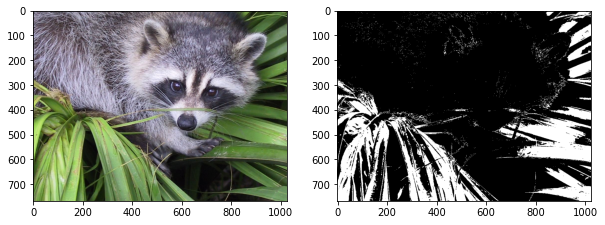

```python
filtro =(mapache[:, : , 0] > 0.2) * (mapache[:, : , 0] < 0.7) * (mapache[:, : , 1] > 0.4) * (mapache[:, : , 1] < 0.8)*  (mapache[:, : , 2] > 0.1) * (mapache[:, : , 2] < 0.45)
filtro2=filtro.astype("int")
plt.figure(figsize=(10,10))
plt.subplot(1,2,1)
plt.imshow(mapache, vmin=0, vmax=1)

plt.subplot(1,2,2)
plt.imshow(filtro2, vmin=0, vmax=1, cmap="gray")
```

- El negro es bajos valores en las tres componentes.
- El blanco es altos valores en las tres componentes.

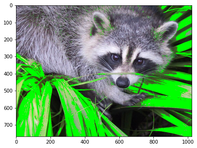

```python
plt.figure(figsize=(10,5))
mapache2 = np.copy(mapache[:,:,:3])
ind = np.argwhere(filtro2)
mapache2[ind[:,0],ind[:,1],1]=1
mapache2[ind[:,0],ind[:,1],0]=0
mapache2[ind[:,0],ind[:,1],2]=0
plt.imshow(mapache2, vmin=0,vmax=1)
```

```python
print(mapache[:, : , 0][740,1000]),
print(mapache[:, : , 1][740,1000]),
print(mapache[:, : , 2][740,1000])
```

```
0.44313726
0.5921569
0.4
```

```python
print(mapache[:, : , 0][525,965]),
print(mapache[:, : , 1][525,965]),
print(mapache[:, : , 2][525,965])
```

```
0.59607846
0.78039217
0.4745098
```